# Prosper Loan Exploration by Benjamin Lee

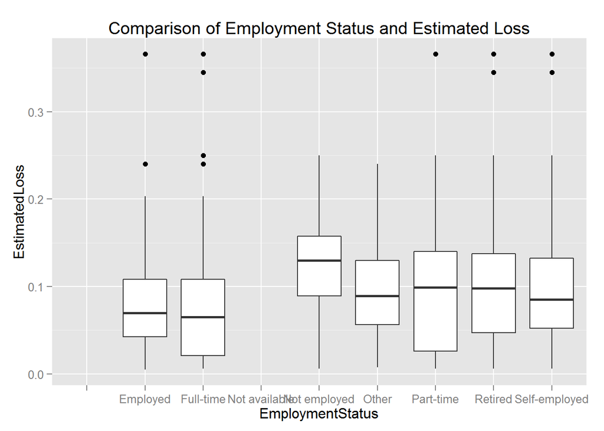

[output not shown]

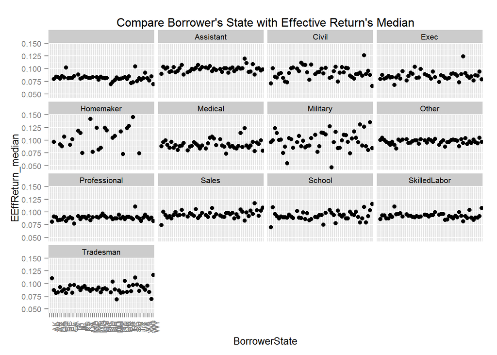

[output not shown]

[figure not shown]

[output not shown]

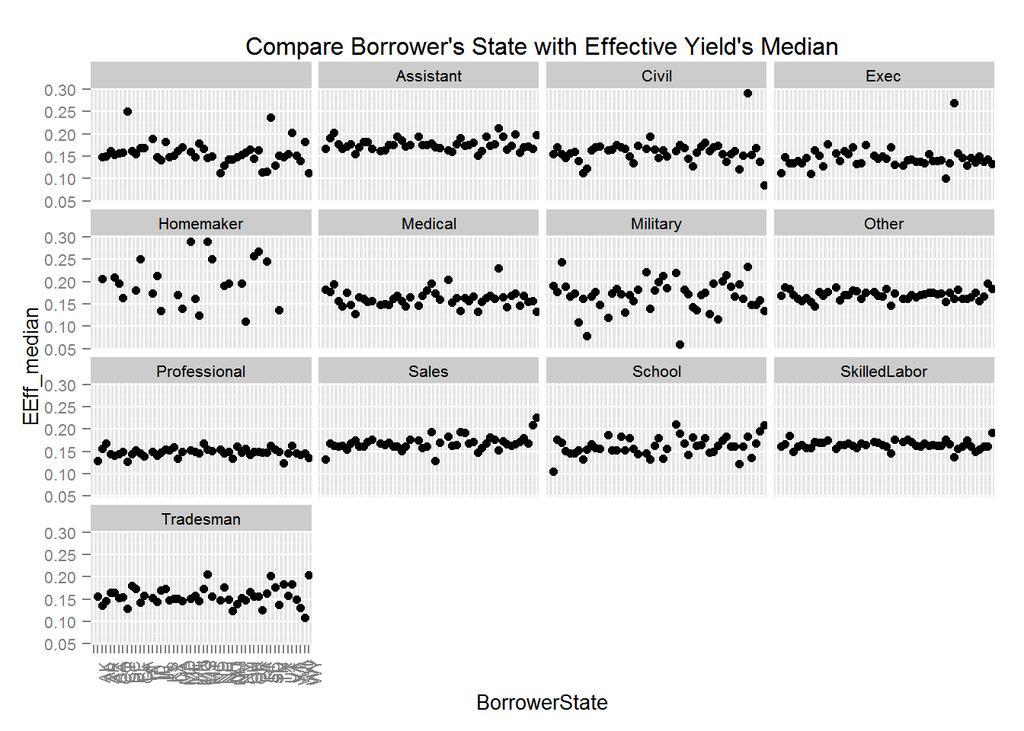

Compare occupation category and return/loss/yield. Difficult to tell if there’s a relationship.

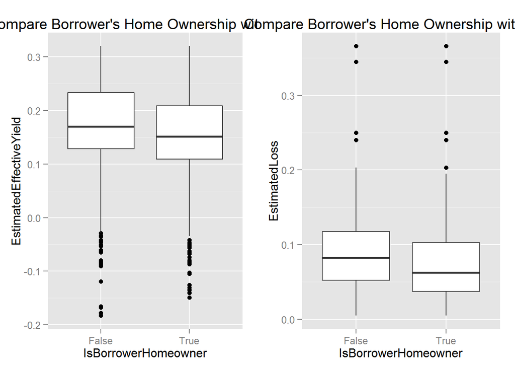

Not been a homeowner has a slight higher risk, as a result, higher rate.

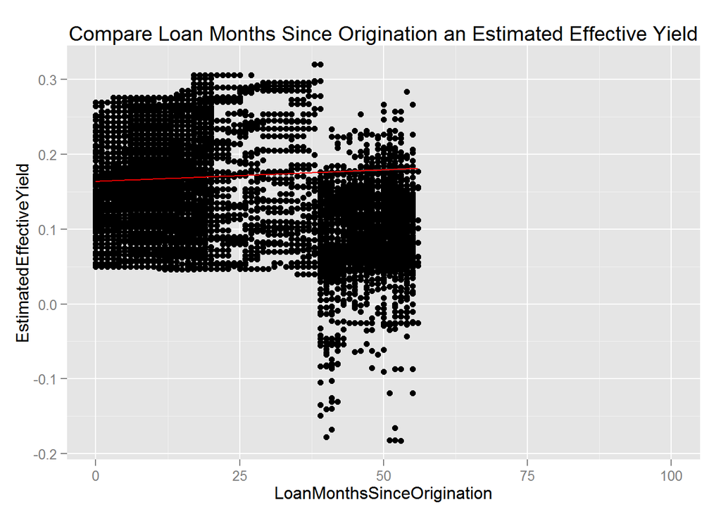

And it seems when loan reaches month 38, we are start seeing failures.

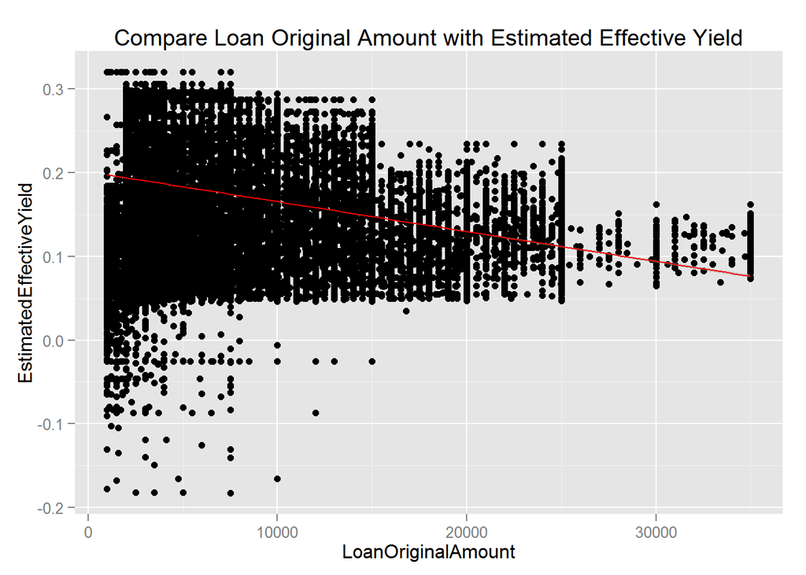

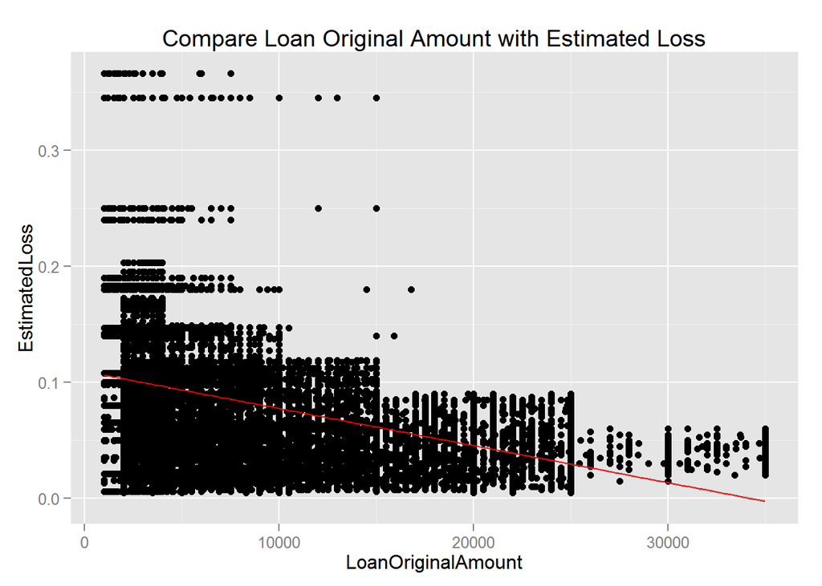

Some smaller loan will failures. Larger loans are less likely to have a loss.

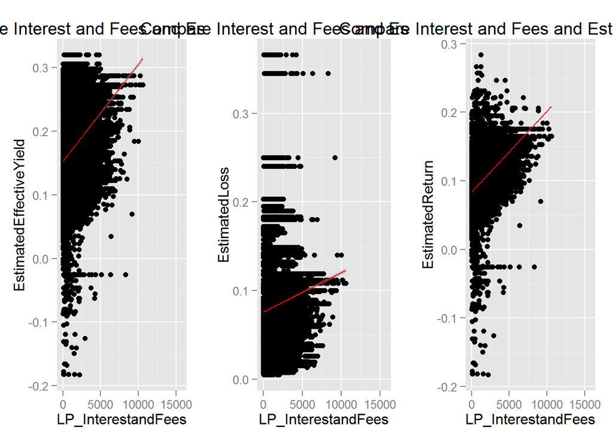

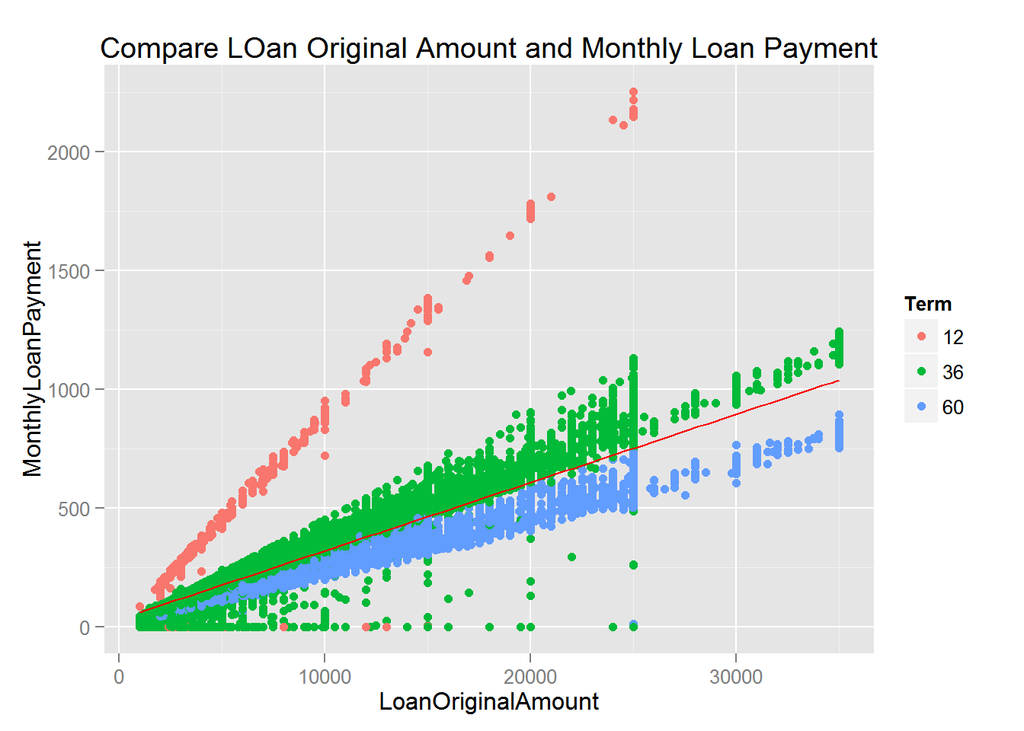

The scale of payment with respect to Term length.

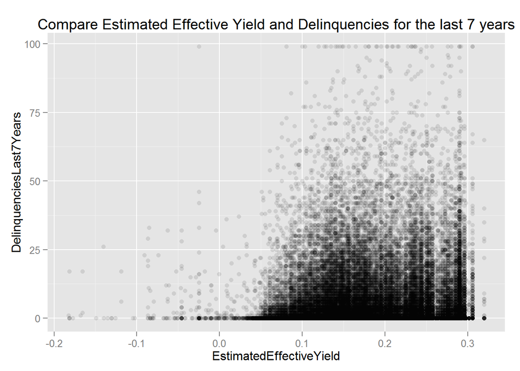

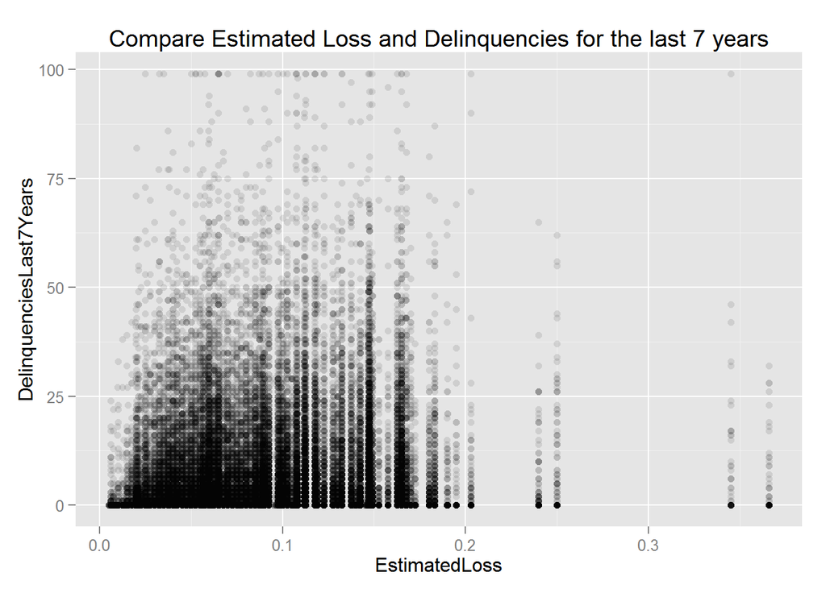

It’s hard to link delinquency with estimated yield or loss.

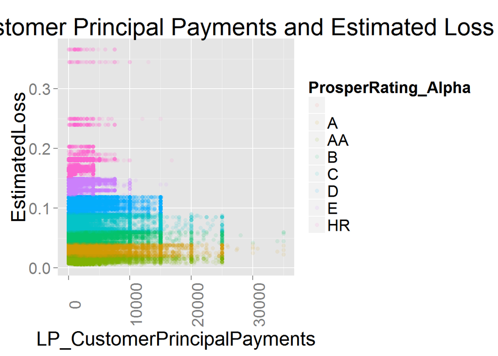

More principal payment means less likely ends up with a loss. This diagram has a strong base of highly rated borrower consistitues of no or low loss.

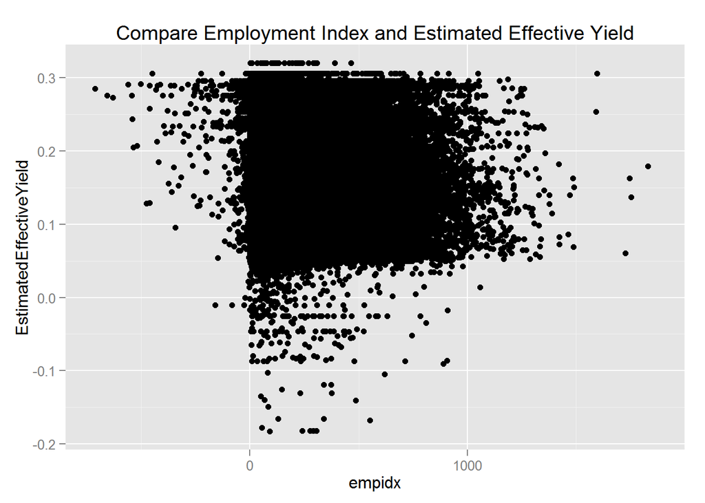

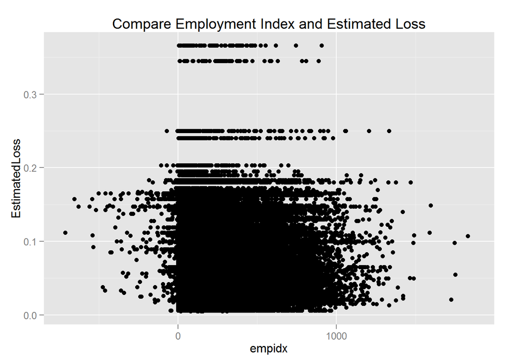

There doesn’t appear to be any relationship between empolyment index I created and loss/yield.

# Multivariate Analysis

### Talk about some of the relationships you observed in this part of the investigation. Were there features that strengthened each other in terms of looking at your feature(s) of interest?

Yield (EstimatdEffectiveYield) are closely related to rating (ProsperRating_Alpha). Ratings are closely related to each other. In this case, I am selecting ProsperRating_Alpha as the choice for study.  
Loan status of all kinds are dispersed with rating systems.  
Further study into the rating system found when rating is left as blank, we have a significant amount of loan failures (chargeoff and defaults).  
### Were there any interesting or surprising interactions between features? Estimated return demonstrates an interesting behavior:  
1. Loan rates tightens around loan ratings over time.  
2. Loan rates also separates clearly around each ratings’ tight range over time.  
In other words, prosper loan has been maturing and settles via market force over time.

Call:  
lm(formula = I(EstimatedEffectiveYield) ~ IsBorrowerHomeowner +  
ProsperRating_numeric + LoanOriginationQuarter + DebtToIncomeRatio +  
ListingCategory_numeric + EmploymentStatus + EmploymentStatusDuration +  
occupationCategory + LoanMonthsSinceOrigination + LP_CustomerPrincipalPayments +  
LP_InterestandFees, data = loan)

Residuals:  
Min 1Q Median 3Q Max  
-0.37645 -0.01064 0.00124 0.01207 0.16478

Coefficients:  
Estimate Std. Error t value Pr(>|t|)  
(Intercept) 1.208e-01 7.842e-03 15.404 < 2e-16 ***  
IsBorrowerHomeownerTrue 5.182e-04 1.731e-04 2.994 0.00276 **  
ProsperRating_numeric2 -1.710e-03 4.027e-04 -4.245 2.19e-05 ***  
ProsperRating_numeric3 -4.140e-02 3.800e-04 -108.963 < 2e-16 ***  
ProsperRating_numeric4 -8.097e-02 3.756e-04 -215.612 < 2e-16 ***  
ProsperRating_numeric5 -1.161e-01 3.825e-04 -303.486 < 2e-16 ***  
ProsperRating_numeric6 -1.490e-01 3.870e-04 -384.974 < 2e-16 ***  
ProsperRating_numeric7 -1.743e-01 4.687e-04 -371.831 < 2e-16 ***  
LoanOriginationQuarter2009 Q4 9.281e-03 1.231e-03 7.537 4.85e-14 ***  
LoanOriginationQuarter2010 Q1 8.857e-03 1.360e-03 6.514 7.34e-11 ***  
LoanOriginationQuarter2010 Q2 7.486e-03 1.481e-03 5.056 4.30e-07 ***  
LoanOriginationQuarter2010 Q3 -2.455e-03 1.710e-03 -1.436 0.15106  
LoanOriginationQuarter2010 Q4 -5.768e-03 1.939e-03 -2.974 0.00294 **  
LoanOriginationQuarter2011 Q1 8.784e-02 2.190e-03 40.111 < 2e-16 ***  
LoanOriginationQuarter2011 Q2 9.485e-02 2.425e-03 39.117 < 2e-16 ***  
LoanOriginationQuarter2011 Q3 1.068e-01 2.689e-03 39.727 < 2e-16 ***  
LoanOriginationQuarter2011 Q4 1.081e-01 2.967e-03 36.427 < 2e-16 ***  
LoanOriginationQuarter2012 Q1 1.040e-01 3.251e-03 31.975 < 2e-16 ***  
LoanOriginationQuarter2012 Q2 1.145e-01 3.545e-03 32.298 < 2e-16 ***  
LoanOriginationQuarter2012 Q3 1.159e-01 3.828e-03 30.278 < 2e-16 ***  
LoanOriginationQuarter2012 Q4 1.087e-01 4.114e-03 26.410 < 2e-16 ***  
LoanOriginationQuarter2013 Q1 1.037e-01 4.439e-03 23.364 < 2e-16 ***  
LoanOriginationQuarter2013 Q2 1.092e-01 4.727e-03 23.101 < 2e-16 ***  
LoanOriginationQuarter2013 Q3 1.123e-01 5.016e-03 22.394 < 2e-16 ***  
LoanOriginationQuarter2013 Q4 1.081e-01 5.312e-03 20.355 < 2e-16 ***  
LoanOriginationQuarter2014 Q1 1.084e-01 5.579e-03 19.429 < 2e-16 ***  
DebtToIncomeRatio 2.398e-03 2.657e-04 9.025 < 2e-16 ***  
ListingCategory_numeric1-DebtConsolidation 4.652e-03 5.296e-03 0.878 0.37975  
ListingCategory_numeric2-HomeImprovement 4.570e-03 5.303e-03 0.862 0.38874  
ListingCategory_numeric3-Business 6.721e-03 5.309e-03 1.266 0.20553  
ListingCategory_numeric5-StudentUse -9.662e-03 5.553e-03 -1.740 0.08188 .  
ListingCategory_numeric6-Auto 4.856e-03 5.319e-03 0.913 0.36126  
ListingCategory_numeric7-Other 5.506e-03 5.301e-03 1.039 0.29895  
ListingCategory_numeric8-Baby&Adoption 5.408e-03 5.553e-03 0.974 0.33017  
ListingCategory_numeric9-Boat 2.011e-04 5.871e-03 0.034 0.97267  
ListingCategory_numeric10-CosmeticProcedure 5.210e-03 5.878e-03 0.886 0.37542  
ListingCategory_numeric11-EngagementRing 2.830e-03 5.541e-03 0.511 0.60953  
ListingCategory_numeric12-GreenLoans 5.379e-03 6.294e-03 0.855 0.39280  
ListingCategory_numeric13-HouseholdExpenses 7.528e-03 5.324e-03 1.414 0.15736  
ListingCategory_numeric14-LargePurchases 6.095e-03 5.358e-03 1.138 0.25528  
ListingCategory_numeric15-Medical/Dental 6.442e-03 5.331e-03 1.208 0.22689  
ListingCategory_numeric16-Motorcycle 5.406e-03 5.468e-03 0.989 0.32280  
ListingCategory_numeric17-RV 7.594e-03 6.221e-03 1.221 0.22219  
ListingCategory_numeric18-Taxes 4.367e-03 5.359e-03 0.815 0.41517  
ListingCategory_numeric19-Vacation 4.806e-03 5.365e-03 0.896 0.37040  
ListingCategory_numeric20-WeddingLoans 6.900e-03 5.365e-03 1.286 0.19838  
EmploymentStatusFull-time -9.069e-03 4.260e-04 -21.289 < 2e-16 ***  
EmploymentStatusNot employed -3.062e-02 2.309e-02 -1.326 0.18476  
EmploymentStatusOther 2.098e-03 5.317e-04 3.946 7.94e-05 ***  
EmploymentStatusPart-time -1.370e-02 1.704e-03 -8.043 8.92e-16 ***  
EmploymentStatusRetired -9.590e-03 1.327e-03 -7.226 5.02e-13 ***  
EmploymentStatusSelf-employed -5.391e-03 3.571e-03 -1.509 0.13118  
EmploymentStatusDuration 6.071e-07 8.839e-07 0.687 0.49218  
occupationCategoryAssistant 2.372e-03 8.824e-04 2.688 0.00719 **  
occupationCategoryCivil 1.545e-03 9.954e-04 1.552 0.12072  
occupationCategoryExec 5.030e-04 9.320e-04 0.540 0.58944  
occupationCategoryHomemaker 6.816e-03 4.992e-03 1.365 0.17210  
occupationCategoryMedical 1.340e-03 9.131e-04 1.467 0.14230  
occupationCategoryMilitary -5.320e-03 1.108e-03 -4.800 1.59e-06 ***  
occupationCategoryOther 1.868e-03 8.211e-04 2.275 0.02290 *  
occupationCategoryProfessional 6.583e-04 8.553e-04 0.770 0.44149  
occupationCategorySales 2.139e-03 8.929e-04 2.396 0.01658 *  
occupationCategorySchool 7.319e-04 9.215e-04 0.794 0.42709  
occupationCategorySkilledLabor 2.180e-03 8.861e-04 2.460 0.01388 *  
occupationCategoryTradesman 2.915e-03 1.066e-03 2.734 0.00626 **  
LoanMonthsSinceOrigination 1.272e-03 1.033e-04 12.317 < 2e-16 ***  
LP_CustomerPrincipalPayments -6.527e-07 2.798e-08 -23.324 < 2e-16 ***  
LP_InterestandFees 6.046e-06 9.323e-08 64.856 < 2e-16 ***  
—  
Signif. codes: 0 ‘**’ 0.001 ’**’ 0.01 ’’ 0.05 ‘.’ 0.1 ‘’ 1

Residual standard error: 0.02307 on 77475 degrees of freedom  
(36394 observations deleted due to missingness)  
Multiple R-squared: 0.8829, Adjusted R-squared: 0.8828  
F-statistic: 8721 on 67 and 77475 DF, p-value: < 2.2e-16  
——

# Final Plots and Summary

### Plot One

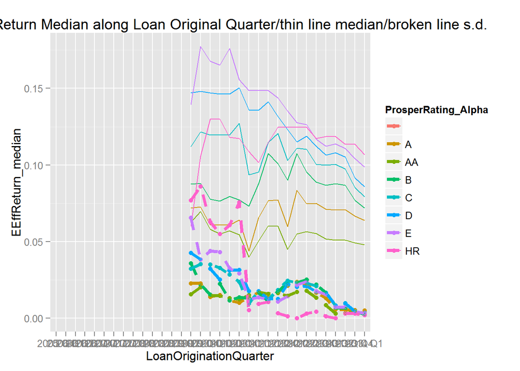

[figure not shown]

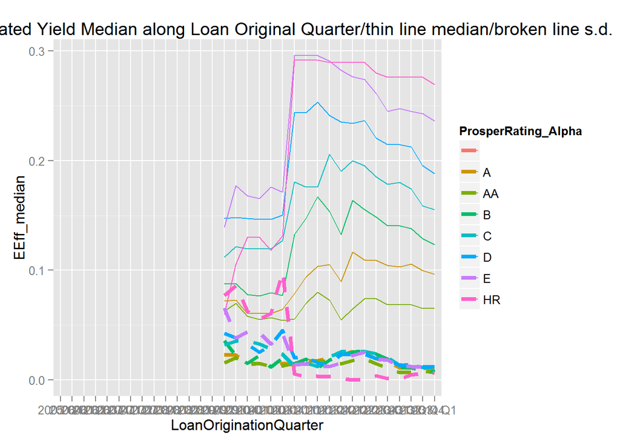

### Plot Two

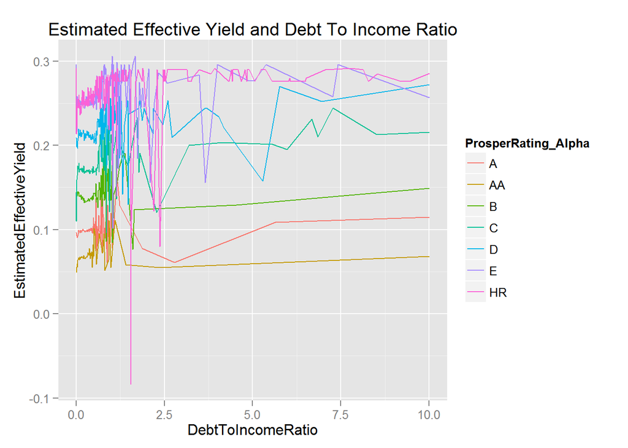

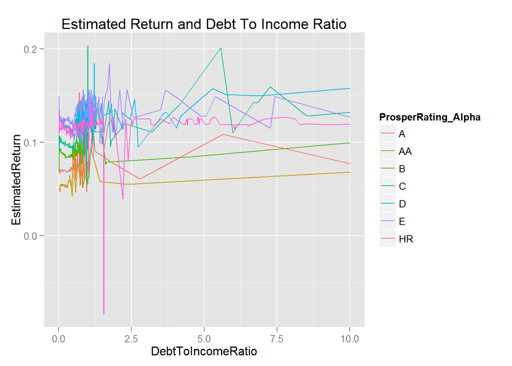

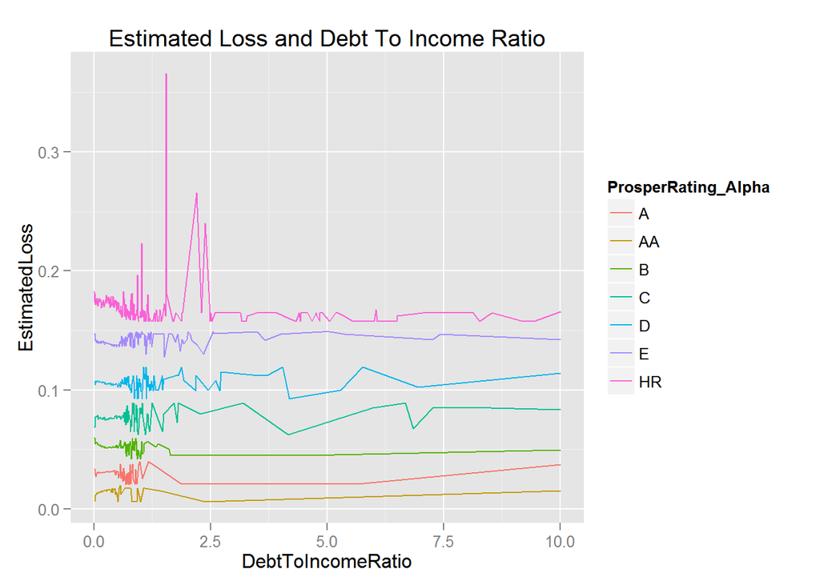

### Description Two

These diagrams shows DebtToIncomeRatio does not affect the yield/loss/return curve as I believe they should. However, there is a rather large jitter at the lower end of this ratio.

### Plot Three

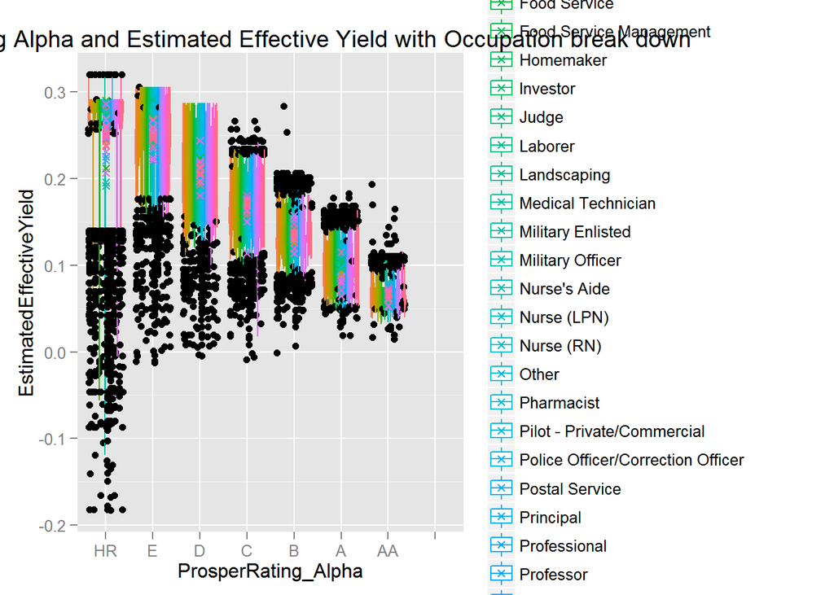

### Description Three

In these diagrams, I have illustrated the ProsperRating_Alpha as an important variable to determine yield, but the various occupation does not seems to have a clear indication one way or the other.

# Reflection

This project proves to be longer and bigger than I thought it should. In certain ways it is exhausting and frustrating to grip with data which turns to be futile. All adults have certain understanding how the financial world works. Although the system can be called ‘inefficient’, but in this example, I think it proves quite otherwise. Although it did take a while.

To a degree, I am suspecting my lack of clear finding is simply a correspondent to the fact many brillant people have been working tirelessly to make some money in this system. In the end, all the forces may just equalizes and the system returns to equilibrium. Otherwise, if such simple and clean system can be easily constructed, then it is an obvious investment opportunity. As indicated in the trend drawing, the system is tighting down.

On the other hand, there are very frustrating times when parameters should work for to build a system intuitively, they frequently don’t. We can suspect if the data has not be collected with enough detail to describe the conter-intuitive behavior (such as Listig Reasons). Of course, it is also possible for consumer behavior to be random in the first place (such as in the case of occupation).

In the end, it seems I need to continue to construct new ways to analyze data. What we have learnt from the class is a starting point very nicely introduce function conversion to linearity in order to build a nice model. What happens when this type of relationship is not obvious?